# Test a Perceptual Phenomenon

### Analyzing the Stroop Effect

Perform the analysis in the space below. Remember to follow [the instructions](https://docs.google.com/document/d/1-OkpZLjG_kX9J6LIQ5IltsqMzVWjh36QpnP2RYpVdPU/pub?embedded=True) and review the [project rubric](https://review.udacity.com/#!/rubrics/71/view) before submitting. Once you've completed the analysis and write-up, download this file as a PDF or HTML file, upload that PDF/HTML into the workspace here (click on the orange Jupyter icon in the upper left then Upload), then use the Submit Project button at the bottom of this page. This will create a zip file containing both this .ipynb doc and the PDF/HTML doc that will be submitted for your project.

(1) What is the independent variable? What is the dependent variable?

**Answer:**

Independent variable is congruent or incongruent words. Dependent variable is measured time to name the ink colors in words.

(2) What is an appropriate set of hypotheses for this task? Specify your null and alternative hypotheses, and clearly define any notation used. Justify your choices.

H0: The difference in the mean measured time to name the ink colors of congruent words and incongruent words is zero

H1: The difference in the mean measured time to name the ink colors of congruent words and incongruent words is less than 0

The population mean of measured time to name ink colors are as follows

μc: Population mean of measured time of naming congruent words

μi: Population mean of measured time of naming incongruent words

H0: μc - μi = 0

H1: μc - μi < 0

Since the dataset has few samples, less than 30, using a t-test is appropriate.

Based on the measured time of naming congruent and incongruent set of words, by the t-test, the difference between the two means of the population symbolized by μc for the congruent words and by μi by incongruent can be infered.

To test them, we will run a one-tailed t-test using a confidence level of 95%, α 0.05.

(3) Report some descriptive statistics regarding this dataset. Include at least one measure of central tendency and at least one measure of variability. The name of the data file is 'stroopdata.csv'.

```python
# Perform the analysis here
import pandas as pd
stroop_df = pd.read_csv('./stroopdata.csv')
stroop_df.describe()
```

|  | Congruent | Incongruent |
| --- | --- | --- |
| count | 24.000000 | 24.000000 |
| mean | 14.051125 | 22.015917 |
| std | 3.559358 | 4.797057 |
| min | 8.630000 | 15.687000 |
| 25% | 11.895250 | 18.716750 |
| 50% | 14.356500 | 21.017500 |
| 75% | 16.200750 | 24.051500 |
| max | 22.328000 | 35.255000 |

**Answer:**

Measure of central tendency:

mean of congruent values: 14.051125

mean of incongruent values: 22.015917

median of congruent values: 14.356500

median of incongruent values: 21.017500

Measure of variability:

sample std of congruent values: 3.559358

sample std of incongruent values: 4.797057

(4) Provide one or two visualizations that show the distribution of the sample data. Write one or two sentences noting what you observe about the plot or plots.

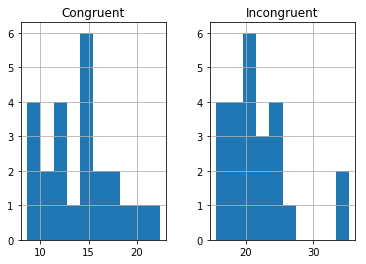

```python
stroop_df.hist();
```

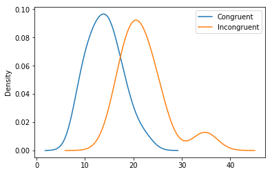

```python
ax = stroop_df.plot.kde()
```

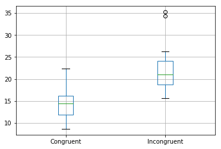

```python
stroop_df.boxplot(column=['Congruent', 'Incongruent']);
```

**Answer:**

Histogram plots suggest that both congruent and incongruent values are right-skewed. However with kde plots we see that the distributions are almost normally distributed.

On the boxplot graph, there are two outliers which are subject to skew the mean of incongruent values.

The boxplot graph suggests us that the measured time to name the congruent words is less than incongruent words.

(5) Now, perform the statistical test and report your results. What is your confidence level or Type I error associated with your test? What is your conclusion regarding the hypotheses you set up? Did the results match up with your expectations? **Hint:** Think about what is being measured on each individual, and what statistic best captures how an individual reacts in each environment.

```python
import numpy as np
from scipy import stats
#T-test
stats.ttest_rel(stroop_df.Congruent,stroop_df.Incongruent)
```

```
Ttest_relResult(statistic=-8.020706944109957, pvalue=4.103000585711178e-08)
```

```python
#T-critical  value is obtained from t-Table and when considering a one-tailed 95% confident level α=0.05
stats.t.ppf(1-0.95, (len(stroop_df)-1))
```

```
-1.7138715277470473
```

**Conclusion:**

Based on the confidence level 95% in one tailed t-test, we found that the value of the t-test is much lower than t-critical. Therefore we reject the null hypothesis, which means that we have found significant statistics to claim that people read a set of congruent words faster than incongruent words.

(6) Optional: What do you think is responsible for the effects observed? Can you think of an alternative or similar task that would result in a similar effect? Some research about the problem will be helpful for thinking about these two questions!